# Difference-in-Differences Multi-Period Data Analysis

Data Description Report

2025-10-18

# Overview

This report describes the difference-in-differences multi-period datasets located in `output/difference_in_differences_multiperiods/`.

## Data Context

The datasets contain panel data with **staggered treatment adoption**:

- **Panel structure**: Multiple units observed over multiple time periods
- **Staggered interventions**: Different units receive treatment at different time points (periods 5, 6, 7, 8)
- **Covariates**: Unit-level covariates (x1_i, x2_i) that affect both treatment assignment (selection) and outcomes
- **Treatment persistence**: Once treated, units remain treated in subsequent periods

## Analysis Plan

### Objective

Estimate the **Average Treatment Effect on the Treated (ATT)** accounting for: 1. Staggered treatment timing across units 2. Selection on observables (covariate confounding)

### Method: Callaway and Sant’Anna (2021)

We will use the **`did`** R package, which implements the Callaway and Sant’Anna (2021) estimator for difference-in-differences with multiple time periods.

**Key features of this method:**

1. **Group-Time ATT**: Estimates treatment effects for each treatment cohort (group) at each time period
2. **Covariate adjustment**: Incorporates covariates to satisfy conditional parallel trends assumption
3. **Three estimator options**:
   - Outcome regression
   - Inverse probability weighting (IPW)
   - Doubly robust (default - combines both)
4. **Proper comparison groups**: Uses not-yet-treated or never-treated units as controls
5. **Aggregation flexibility**: Can aggregate to overall ATT, event study effects, group-specific effects, or calendar time effects

**Required variables:**

- `yname`: Outcome variable (y_it)
- `tname`: Time period (time)
- `idname`: Unit identifier (id)
- `gname`: Treatment timing group (first period of treatment; 0 if never treated)
- `xformla`: Covariate formula (~x1_i + x2_i)

**Main functions:**

- `att_gt()`: Estimates group-time average treatment effects
- `aggte()`: Aggregates group-time effects into summary measures
- `ggdid()`: Visualizes results

# Load Data

```r
# Load the three datasets
df_cov <- readRDS(here("output/difference_in_differences_multiperiods/df_design_cov.rds"))
df_nocov <- readRDS(here("output/difference_in_differences_multiperiods/df_design_nocov.rds"))
df_nyt <- readRDS(here("output/difference_in_differences_multiperiods/df_design_nyt.rds"))
```

# Dataset 1: With Covariates (df_design_cov)

## Structure

```r
str(df_cov)
```

```
## tibble [10,000 × 20] (S3: tbl_df/tbl/data.frame)
##  $ id     : int [1:10000] 1 2 3 4 5 6 7 8 9 10 ...
##  $ x1_i   : logi [1:10000] TRUE TRUE FALSE TRUE TRUE TRUE ...
##  $ x2_i   : logi [1:10000] TRUE FALSE FALSE FALSE TRUE TRUE ...
##  $ group_i: num [1:10000] 0 0 0 5 5 5 0 5 6 6 ...
##  $ g5_i   : logi [1:10000] FALSE FALSE FALSE TRUE TRUE TRUE ...
##  $ g6_i   : logi [1:10000] FALSE FALSE FALSE FALSE FALSE FALSE ...
##  $ g7_i   : logi [1:10000] FALSE FALSE FALSE FALSE FALSE FALSE ...
##  $ g8_i   : logi [1:10000] FALSE FALSE FALSE FALSE FALSE FALSE ...
##  $ time   : int [1:10000] 1 1 1 1 1 1 1 1 1 1 ...
##  $ tau_it : num [1:10000] 0 0 0 0.1887 0.0822 ...
##  $ tau_t  : num [1:10000] 0.926 0.926 0.926 0.926 0.926 ...
##  $ z_it   : num [1:10000] 0 0 0 0 0 0 0 0 0 0 ...
##  $ z5_it  : num [1:10000] 0 0 0 0 0 0 0 0 0 0 ...
##  $ z6_it  : num [1:10000] 0 0 0 0 0 0 0 0 0 0 ...
##  $ z7_it  : num [1:10000] 0 0 0 0 0 0 0 0 0 0 ...
##  $ z8_it  : num [1:10000] 0 0 0 0 0 0 0 0 0 0 ...
##  $ y0_it  : num [1:10000] 5.2 5.42 5.41 5.12 5.17 ...
##  $ y_it   : num [1:10000] 5.2 5.42 5.41 5.12 5.17 ...
##  $ group  : chr [1:10000] "control" "control" "control" "treat" ...
##  $ groupx : chr [1:10000] "1,1" "1,0" "0,0" "1,0" ...
```

## Summary Statistics

### Numeric Variables

```r
numeric_vars <- df_cov %>% select(where(is.numeric))
if(ncol(numeric_vars) > 0) {
  numeric_summary <- data.frame(
    Variable = names(numeric_vars),
    Min = sapply(numeric_vars, min, na.rm = TRUE),
    Q1 = sapply(numeric_vars, quantile, 0.25, na.rm = TRUE),
    Median = sapply(numeric_vars, median, na.rm = TRUE),
    Mean = sapply(numeric_vars, mean, na.rm = TRUE),
    Q3 = sapply(numeric_vars, quantile, 0.75, na.rm = TRUE),
    Max = sapply(numeric_vars, max, na.rm = TRUE),
    SD = sapply(numeric_vars, sd, na.rm = TRUE),
    N_Missing = sapply(numeric_vars, function(x) sum(is.na(x)))
  )
  rownames(numeric_summary) <- NULL

  numeric_summary %>%
    kable(digits = 3) %>%
    kable_styling(bootstrap_options = c("striped", "hover", "condensed"))
}
```

| Variable | Min | Q1 | Median | Mean | Q3 | Max | SD | N_Missing |
| --- | --- | --- | --- | --- | --- | --- | --- | --- |
| id | 1.000 | 250.750 | 500.500 | 500.500 | 750.250 | 1000.000 | 288.689 | 0 |
| group_i | 0.000 | 0.000 | 5.000 | 3.731 | 5.000 | 8.000 | 2.691 | 0 |
| time | 1.000 | 3.000 | 5.500 | 5.500 | 8.000 | 10.000 | 2.872 | 0 |
| tau_it | -1.440 | 0.000 | 0.000 | -0.002 | 0.130 | 0.721 | 0.278 | 0 |
| tau_t | 0.914 | 0.926 | 0.962 | 0.979 | 1.035 | 1.072 | 0.059 | 0 |
| z_it | 0.000 | 0.000 | 0.000 | 0.369 | 1.000 | 1.000 | 0.483 | 0 |
| z5_it | 0.000 | 0.000 | 0.000 | 0.274 | 1.000 | 1.000 | 0.446 | 0 |
| z6_it | 0.000 | 0.000 | 0.000 | 0.064 | 0.000 | 1.000 | 0.245 | 0 |
| z7_it | 0.000 | 0.000 | 0.000 | 0.017 | 0.000 | 1.000 | 0.129 | 0 |
| z8_it | 0.000 | 0.000 | 0.000 | 0.014 | 0.000 | 1.000 | 0.119 | 0 |
| y0_it | 3.561 | 4.992 | 5.308 | 5.305 | 5.658 | 6.824 | 0.590 | 0 |
| y_it | 2.642 | 4.969 | 5.335 | 5.315 | 5.690 | 7.291 | 0.659 | 0 |

### Logical Variables

```r
logical_vars <- df_cov %>% select(where(is.logical))
if(ncol(logical_vars) > 0) {
  logical_summary <- data.frame(
    Variable = names(logical_vars),
    N_TRUE = sapply(logical_vars, function(x) sum(x, na.rm = TRUE)),
    N_FALSE = sapply(logical_vars, function(x) sum(!x, na.rm = TRUE)),
    N_Missing = sapply(logical_vars, function(x) sum(is.na(x))),
    Prop_TRUE = sapply(logical_vars, function(x) mean(x, na.rm = TRUE))
  )
  rownames(logical_summary) <- NULL

  logical_summary %>%
    kable(digits = 3) %>%
    kable_styling(bootstrap_options = c("striped", "hover", "condensed"))
}
```

| Variable | N_TRUE | N_FALSE | N_Missing | Prop_TRUE |
| --- | --- | --- | --- | --- |
| x1_i | 6890 | 3110 | 0 | 0.689 |
| x2_i | 3200 | 6800 | 0 | 0.320 |
| g5_i | 4570 | 5430 | 0 | 0.457 |
| g6_i | 1280 | 8720 | 0 | 0.128 |
| g7_i | 420 | 9580 | 0 | 0.042 |
| g8_i | 480 | 9520 | 0 | 0.048 |

### Character Variables

```r
character_vars <- df_cov %>% select(where(is.character))
if(ncol(character_vars) > 0) {
  character_summary <- data.frame(
    Variable = names(character_vars),
    N_Unique = sapply(character_vars, function(x) length(unique(x))),
    N_Missing = sapply(character_vars, function(x) sum(is.na(x) | x == "")),
    Most_Common = sapply(character_vars, function(x) {
      tbl <- table(x)
      if(length(tbl) > 0) names(tbl)[which.max(tbl)] else NA
    }),
    Most_Common_Count = sapply(character_vars, function(x) {
      tbl <- table(x)
      if(length(tbl) > 0) max(tbl) else NA
    })
  )
  rownames(character_summary) <- NULL

  character_summary %>%
    kable(digits = 3) %>%
    kable_styling(bootstrap_options = c("striped", "hover", "condensed"))
}
```

| Variable | N_Unique | N_Missing | Most_Common | Most_Common_Count |
| --- | --- | --- | --- | --- |
| group | 2 | 0 | treat | 6750 |
| groupx | 3 | 0 | 1,0 | 3690 |

## Dimensions

```r
cat("Number of observations:", nrow(df_cov), "\n")
```

```
## Number of observations: 10000
```

```r
cat("Number of variables:", ncol(df_cov), "\n")
```

```
## Number of variables: 20
```

## First Few Rows

```r
head(df_cov, 10) %>%
  kable() %>%
  kable_styling(bootstrap_options = c("striped", "hover", "condensed")) %>%
  scroll_box(width = "100%")
```

| id | x1_i | x2_i | group_i | g5_i | g6_i | g7_i | g8_i | time | tau_it | tau_t | z_it | z5_it | z6_it | z7_it | z8_it | y0_it | y_it | group | groupx |
| --- | --- | --- | --- | --- | --- | --- | --- | --- | --- | --- | --- | --- | --- | --- | --- | --- | --- | --- | --- |
| 1 | TRUE | TRUE | 0 | FALSE | FALSE | FALSE | FALSE | 1 | 0.0000000 | 0.925653 | 0 | 0 | 0 | 0 | 0 | 5.198205 | 5.198205 | control | 1,1 |
| 2 | TRUE | FALSE | 0 | FALSE | FALSE | FALSE | FALSE | 1 | 0.0000000 | 0.925653 | 0 | 0 | 0 | 0 | 0 | 5.419145 | 5.419145 | control | 1,0 |
| 3 | FALSE | FALSE | 0 | FALSE | FALSE | FALSE | FALSE | 1 | 0.0000000 | 0.925653 | 0 | 0 | 0 | 0 | 0 | 5.413548 | 5.413548 | control | 0,0 |
| 4 | TRUE | FALSE | 5 | TRUE | FALSE | FALSE | FALSE | 1 | 0.1886981 | 0.925653 | 0 | 0 | 0 | 0 | 0 | 5.116601 | 5.116601 | treat | 1,0 |
| 5 | TRUE | TRUE | 5 | TRUE | FALSE | FALSE | FALSE | 1 | 0.0822258 | 0.925653 | 0 | 0 | 0 | 0 | 0 | 5.172495 | 5.172495 | treat | 1,1 |
| 6 | TRUE | TRUE | 5 | TRUE | FALSE | FALSE | FALSE | 1 | 0.2214935 | 0.925653 | 0 | 0 | 0 | 0 | 0 | 5.421068 | 5.421068 | treat | 1,1 |
| 7 | FALSE | FALSE | 0 | FALSE | FALSE | FALSE | FALSE | 1 | 0.0000000 | 0.925653 | 0 | 0 | 0 | 0 | 0 | 5.627297 | 5.627297 | control | 0,0 |
| 8 | TRUE | FALSE | 5 | TRUE | FALSE | FALSE | FALSE | 1 | 0.1500083 | 0.925653 | 0 | 0 | 0 | 0 | 0 | 5.267556 | 5.267556 | treat | 1,0 |
| 9 | TRUE | TRUE | 6 | FALSE | TRUE | FALSE | FALSE | 1 | -0.7511980 | 0.925653 | 0 | 0 | 0 | 0 | 0 | 5.240210 | 5.240210 | treat | 1,1 |
| 10 | TRUE | TRUE | 6 | FALSE | TRUE | FALSE | FALSE | 1 | -0.1351090 | 0.925653 | 0 | 0 | 0 | 0 | 0 | 5.363160 | 5.363160 | treat | 1,1 |

## Variable Distribution

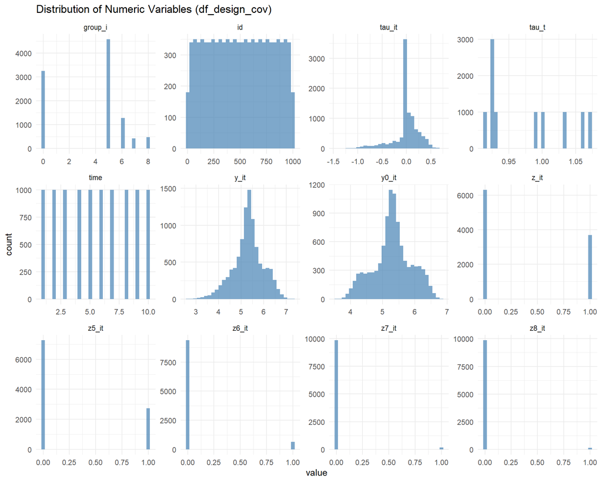

```r
# Select numeric variables for plotting
numeric_vars <- df_cov %>% select(where(is.numeric))

if(ncol(numeric_vars) > 0) {
  numeric_vars %>%
    pivot_longer(everything(), names_to = "variable", values_to = "value") %>%
    ggplot(aes(x = value)) +
    geom_histogram(bins = 30, fill = "steelblue", alpha = 0.7) +
    facet_wrap(~variable, scales = "free") +
    theme_minimal() +
    labs(title = "Distribution of Numeric Variables (df_design_cov)")
}
```

## ATT Estimation using Callaway and Sant’Anna (2021)

### Estimate Group-Time ATT

```r
library(did)

# Estimate group-time average treatment effects
# Using doubly robust estimator with covariates
att_results <- att_gt(
  yname = "y_it",           # Outcome variable
  tname = "time",            # Time period
  idname = "id",             # Unit identifier
  gname = "group_i",         # Treatment timing (0 for never-treated)
  xformla = ~x1_i + x2_i,    # Covariates
  data = df_cov,
  control_group = "nevertreated",  # Use never-treated as comparison
  est_method = "dr"          # Doubly robust estimator
)

# Display summary
summary(att_results)
```

```
##
## Call:
## att_gt(yname = "y_it", tname = "time", idname = "id", gname = "group_i",
##     xformla = ~x1_i + x2_i, data = df_cov, control_group = "nevertreated",
##     est_method = "dr")
##
## Reference: Callaway, Brantly and Pedro H.C. Sant'Anna.  "Difference-in-Differences with Multiple Time Periods." Journal of Econometrics, Vol. 225, No. 2, pp. 200-230, 2021. <https://doi.org/10.1016/j.jeconom.2020.12.001>, <https://arxiv.org/abs/1803.09015>
##
## Group-Time Average Treatment Effects:
##  Group Time ATT(g,t) Std. Error [95% Simult.  Conf. Band]
##      5    2  -0.0025     0.0033       -0.0126      0.0077
##      5    3  -0.0007     0.0036       -0.0117      0.0103
##      5    4   0.0017     0.0032       -0.0081      0.0114
##      5    5   0.1700     0.0073        0.1478      0.1922 *
##      5    6   0.1882     0.0076        0.1652      0.2113 *
##      5    7   0.1755     0.0069        0.1546      0.1965 *
##      5    8   0.1827     0.0070        0.1616      0.2038 *
##      5    9   0.1910     0.0079        0.1671      0.2149 *
##      5   10   0.2045     0.0081        0.1800      0.2289 *
##      6    2  -0.0074     0.0057       -0.0247      0.0099
##      6    3  -0.0024     0.0057       -0.0197      0.0149
##      6    4   0.0021     0.0053       -0.0139      0.0181
##      6    5   0.0059     0.0053       -0.0101      0.0220
##      6    6  -0.4919     0.0269       -0.5734     -0.4105 *
##      6    7  -0.4520     0.0260       -0.5309     -0.3731 *
##      6    8  -0.4498     0.0249       -0.5254     -0.3743 *
##      6    9  -0.4832     0.0268       -0.5643     -0.4020 *
##      6   10  -0.5183     0.0286       -0.6050     -0.4316 *
##      7    2  -0.0005     0.0094       -0.0291      0.0281
##      7    3  -0.0162     0.0086       -0.0423      0.0099
##      7    4   0.0023     0.0089       -0.0247      0.0293
##      7    5  -0.0005     0.0088       -0.0273      0.0263
##      7    6   0.0078     0.0094       -0.0208      0.0363
##      7    7  -0.3813     0.0408       -0.5051     -0.2575 *
##      7    8  -0.3685     0.0412       -0.4934     -0.2436 *
##      7    9  -0.4096     0.0438       -0.5426     -0.2767 *
##      7   10  -0.4409     0.0470       -0.5833     -0.2984 *
##      8    2  -0.0134     0.0080       -0.0378      0.0110
##      8    3   0.0080     0.0075       -0.0148      0.0308
##      8    4  -0.0033     0.0070       -0.0245      0.0180
##      8    5  -0.0022     0.0079       -0.0260      0.0216
##      8    6   0.0026     0.0079       -0.0213      0.0265
##      8    7  -0.0012     0.0068       -0.0219      0.0196
##      8    8  -0.1450     0.0166       -0.1955     -0.0946 *
##      8    9  -0.1573     0.0183       -0.2128     -0.1018 *
##      8   10  -0.1701     0.0194       -0.2290     -0.1112 *
## ---
## Signif. codes: `*' confidence band does not cover 0
##
## P-value for pre-test of parallel trends assumption:  0.49569
## Control Group:  Never Treated,  Anticipation Periods:  0
## Estimation Method:  Doubly Robust
```

### Aggregate to Overall ATT

```r
# Simple weighted average ATT
att_simple <- aggte(att_results, type = "simple")
summary(att_simple)
```

```
##
## Call:
## aggte(MP = att_results, type = "simple")
##
## Reference: Callaway, Brantly and Pedro H.C. Sant'Anna.  "Difference-in-Differences with Multiple Time Periods." Journal of Econometrics, Vol. 225, No. 2, pp. 200-230, 2021. <https://doi.org/10.1016/j.jeconom.2020.12.001>, <https://arxiv.org/abs/1803.09015>
##
##
##     ATT    Std. Error     [ 95%  Conf. Int.]
##  0.0302        0.0122     0.0064      0.0541 *
##
##
## ---
## Signif. codes: `*' confidence band does not cover 0
##
## Control Group:  Never Treated,  Anticipation Periods:  0
## Estimation Method:  Doubly Robust
```

### Event Study / Dynamic Effects

```r
# Dynamic treatment effects (event study)
att_dynamic <- aggte(att_results, type = "dynamic")
summary(att_dynamic)
```

```
##
## Call:
## aggte(MP = att_results, type = "dynamic")
##
## Reference: Callaway, Brantly and Pedro H.C. Sant'Anna.  "Difference-in-Differences with Multiple Time Periods." Journal of Econometrics, Vol. 225, No. 2, pp. 200-230, 2021. <https://doi.org/10.1016/j.jeconom.2020.12.001>, <https://arxiv.org/abs/1803.09015>
##
##
## Overall summary of ATT's based on event-study/dynamic aggregation:
##     ATT    Std. Error     [ 95%  Conf. Int.]
##  0.0394        0.0119     0.0161      0.0627 *
##
##
## Dynamic Effects:
##  Event time Estimate Std. Error [95% Simult.  Conf. Band]
##          -6  -0.0134     0.0080       -0.0351      0.0083
##          -5   0.0040     0.0052       -0.0100      0.0181
##          -4  -0.0082     0.0035       -0.0177      0.0013
##          -3  -0.0021     0.0024       -0.0085      0.0042
##          -2   0.0001     0.0023       -0.0063      0.0064
##          -1   0.0027     0.0023       -0.0036      0.0089
##           0  -0.0122     0.0146       -0.0518      0.0273
##           1   0.0076     0.0127       -0.0267      0.0420
##           2  -0.0040     0.0138       -0.0414      0.0333
##           3   0.0050     0.0144       -0.0341      0.0441
##           4   0.0358     0.0149       -0.0044      0.0761
##           5   0.2045     0.0082        0.1824      0.2266 *
## ---
## Signif. codes: `*' confidence band does not cover 0
##
## Control Group:  Never Treated,  Anticipation Periods:  0
## Estimation Method:  Doubly Robust
```

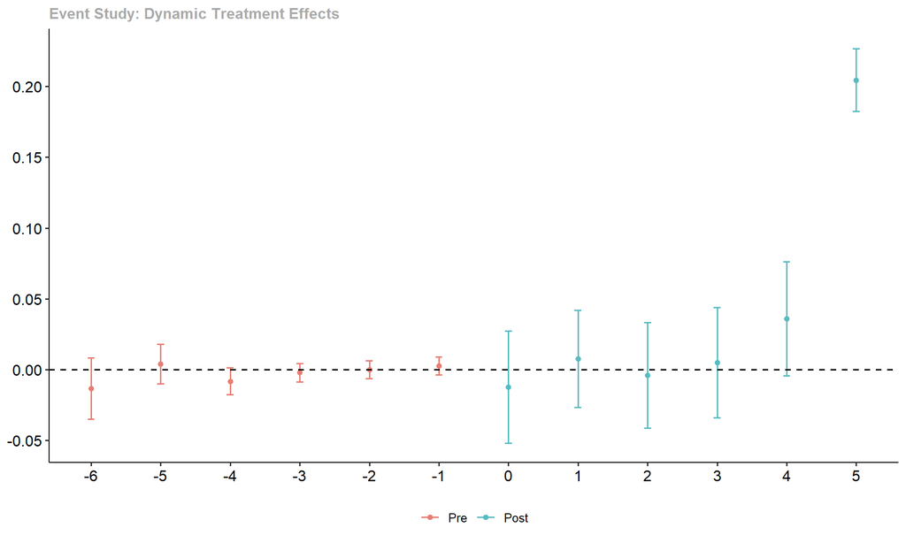

```r
# Plot event study
ggdid(att_dynamic, title = "Event Study: Dynamic Treatment Effects")
```

### Group-Specific ATT

```r
# Group-specific average treatment effects
att_group <- aggte(att_results, type = "group")
summary(att_group)
```

```
##
## Call:
## aggte(MP = att_results, type = "group")
##
## Reference: Callaway, Brantly and Pedro H.C. Sant'Anna.  "Difference-in-Differences with Multiple Time Periods." Journal of Econometrics, Vol. 225, No. 2, pp. 200-230, 2021. <https://doi.org/10.1016/j.jeconom.2020.12.001>, <https://arxiv.org/abs/1803.09015>
##
##
## Overall summary of ATT's based on group/cohort aggregation:
##      ATT    Std. Error     [ 95%  Conf. Int.]
##  -0.0015        0.0267    -0.0538      0.0509
##
##
## Group Effects:
##  Group Estimate Std. Error [95% Simult.  Conf. Band]
##      5   0.1853     0.0071        0.1686      0.2021 *
##      6  -0.4790     0.0273       -0.5430     -0.4151 *
##      7  -0.4001     0.0404       -0.4948     -0.3053 *
##      8  -0.1575     0.0170       -0.1974     -0.1176 *
## ---
## Signif. codes: `*' confidence band does not cover 0
##
## Control Group:  Never Treated,  Anticipation Periods:  0
## Estimation Method:  Doubly Robust
```

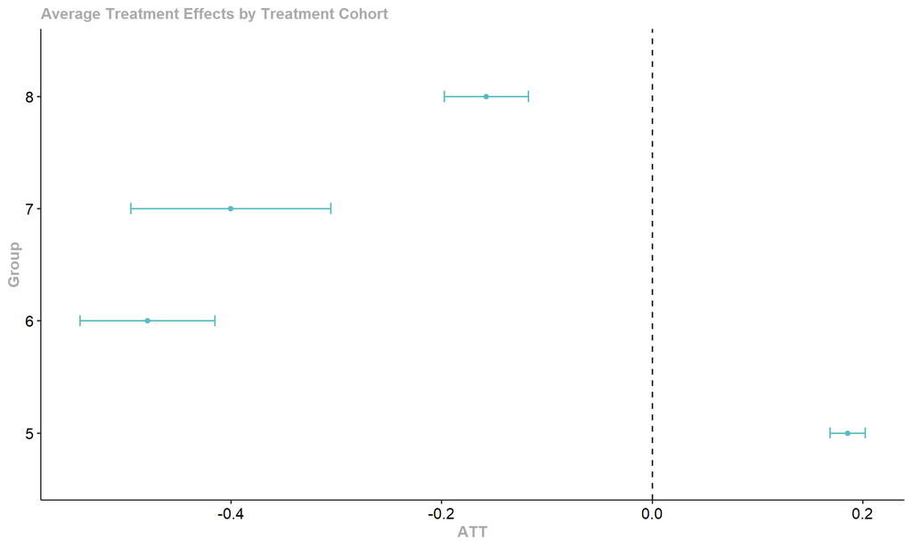

```r
# Plot group-specific effects
ggdid(att_group, title = "Average Treatment Effects by Treatment Cohort")
```

### Calendar Time Effects

```r
# Calendar time average treatment effects
att_calendar <- aggte(att_results, type = "calendar")
summary(att_calendar)
```

```
##
## Call:
## aggte(MP = att_results, type = "calendar")
##
## Reference: Callaway, Brantly and Pedro H.C. Sant'Anna.  "Difference-in-Differences with Multiple Time Periods." Journal of Econometrics, Vol. 225, No. 2, pp. 200-230, 2021. <https://doi.org/10.1016/j.jeconom.2020.12.001>, <https://arxiv.org/abs/1803.09015>
##
##
## Overall summary of ATT's based on calendar time aggregation:
##     ATT    Std. Error     [ 95%  Conf. Int.]
##  0.0377        0.0115     0.0152      0.0603 *
##
##
## Time Effects:
##  Time Estimate Std. Error [95% Simult.  Conf. Band]
##     5   0.1700     0.0068        0.1538      0.1861 *
##     6   0.0394     0.0152        0.0035      0.0753 *
##     7   0.0101     0.0138       -0.0224      0.0426
##     8   0.0052     0.0130       -0.0255      0.0358
##     9   0.0010     0.0136       -0.0311      0.0331
##    10   0.0006     0.0149       -0.0345      0.0358
## ---
## Signif. codes: `*' confidence band does not cover 0
##
## Control Group:  Never Treated,  Anticipation Periods:  0
## Estimation Method:  Doubly Robust
```

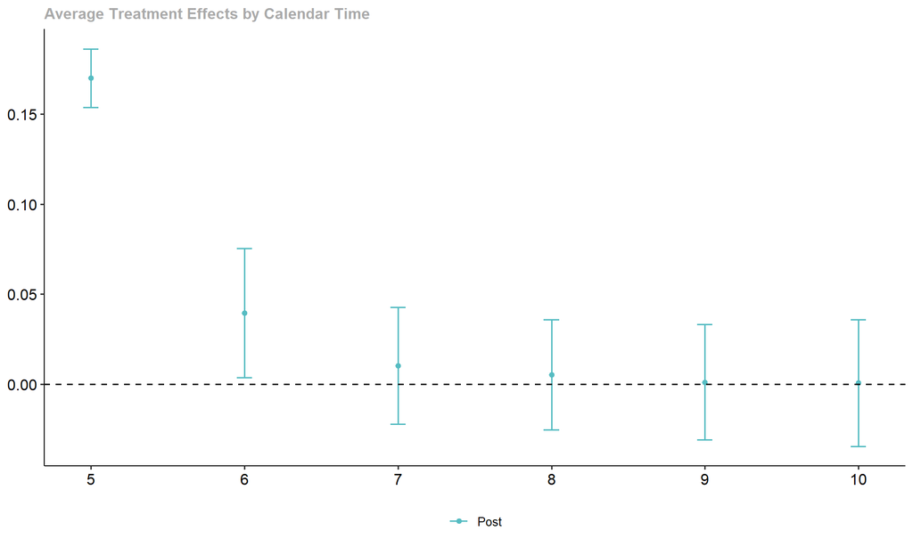

```r
# Plot calendar time effects
ggdid(att_calendar, title = "Average Treatment Effects by Calendar Time")
```

# Dataset 2: Without Covariates (df_design_nocov)

## Structure

```r
str(df_nocov)
```

```
## tibble [10,000 × 18] (S3: tbl_df/tbl/data.frame)
##  $ id     : int [1:10000] 1 2 3 4 5 6 7 8 9 10 ...
##  $ x1_i   : logi [1:10000] TRUE TRUE FALSE TRUE TRUE TRUE ...
##  $ x2_i   : logi [1:10000] TRUE FALSE FALSE FALSE TRUE TRUE ...
##  $ group_i: num [1:10000] 0 0 0 5 5 5 0 5 6 6 ...
##  $ g5_i   : logi [1:10000] FALSE FALSE FALSE TRUE TRUE TRUE ...
##  $ g6_i   : logi [1:10000] FALSE FALSE FALSE FALSE FALSE FALSE ...
##  $ g7_i   : logi [1:10000] FALSE FALSE FALSE FALSE FALSE FALSE ...
##  $ g8_i   : logi [1:10000] FALSE FALSE FALSE FALSE FALSE FALSE ...
##  $ time   : int [1:10000] 1 1 1 1 1 1 1 1 1 1 ...
##  $ tau_it : num [1:10000] 0 0 0 0.1887 0.0822 ...
##  $ tau_t  : num [1:10000] 0.926 0.926 0.926 0.926 0.926 ...
##  $ z_it   : num [1:10000] 0 0 0 0 0 0 0 0 0 0 ...
##  $ z5_it  : num [1:10000] 0 0 0 0 0 0 0 0 0 0 ...
##  $ z6_it  : num [1:10000] 0 0 0 0 0 0 0 0 0 0 ...
##  $ z7_it  : num [1:10000] 0 0 0 0 0 0 0 0 0 0 ...
##  $ z8_it  : num [1:10000] 0 0 0 0 0 0 0 0 0 0 ...
##  $ y0_it  : num [1:10000] 5.43 5.54 5.41 5.24 5.4 ...
##  $ y_it   : num [1:10000] 5.43 5.54 5.41 5.24 5.4 ...
```

## Summary Statistics

### Numeric Variables

```r
numeric_vars <- df_nocov %>% select(where(is.numeric))
if(ncol(numeric_vars) > 0) {
  numeric_summary <- data.frame(
    Variable = names(numeric_vars),
    Min = sapply(numeric_vars, min, na.rm = TRUE),
    Q1 = sapply(numeric_vars, quantile, 0.25, na.rm = TRUE),
    Median = sapply(numeric_vars, median, na.rm = TRUE),
    Mean = sapply(numeric_vars, mean, na.rm = TRUE),
    Q3 = sapply(numeric_vars, quantile, 0.75, na.rm = TRUE),
    Max = sapply(numeric_vars, max, na.rm = TRUE),
    SD = sapply(numeric_vars, sd, na.rm = TRUE),
    N_Missing = sapply(numeric_vars, function(x) sum(is.na(x)))
  )
  rownames(numeric_summary) <- NULL

  numeric_summary %>%
    kable(digits = 3) %>%
    kable_styling(bootstrap_options = c("striped", "hover", "condensed"))
}
```

| Variable | Min | Q1 | Median | Mean | Q3 | Max | SD | N_Missing |
| --- | --- | --- | --- | --- | --- | --- | --- | --- |
| id | 1.000 | 250.750 | 500.500 | 500.500 | 750.250 | 1000.000 | 288.689 | 0 |
| group_i | 0.000 | 0.000 | 5.000 | 3.731 | 5.000 | 8.000 | 2.691 | 0 |
| time | 1.000 | 3.000 | 5.500 | 5.500 | 8.000 | 10.000 | 2.872 | 0 |
| tau_it | -1.440 | 0.000 | 0.000 | -0.002 | 0.130 | 0.721 | 0.278 | 0 |
| tau_t | 0.914 | 0.926 | 0.962 | 0.979 | 1.035 | 1.072 | 0.059 | 0 |
| z_it | 0.000 | 0.000 | 0.000 | 0.369 | 1.000 | 1.000 | 0.483 | 0 |
| z5_it | 0.000 | 0.000 | 0.000 | 0.274 | 1.000 | 1.000 | 0.446 | 0 |
| z6_it | 0.000 | 0.000 | 0.000 | 0.064 | 0.000 | 1.000 | 0.245 | 0 |
| z7_it | 0.000 | 0.000 | 0.000 | 0.017 | 0.000 | 1.000 | 0.129 | 0 |
| z8_it | 0.000 | 0.000 | 0.000 | 0.014 | 0.000 | 1.000 | 0.119 | 0 |
| y0_it | 4.963 | 5.699 | 5.952 | 5.953 | 6.208 | 6.868 | 0.328 | 0 |
| y_it | 4.476 | 5.670 | 5.936 | 5.963 | 6.249 | 7.291 | 0.385 | 0 |

### Logical Variables

```r
logical_vars <- df_nocov %>% select(where(is.logical))
if(ncol(logical_vars) > 0) {
  logical_summary <- data.frame(
    Variable = names(logical_vars),
    N_TRUE = sapply(logical_vars, function(x) sum(x, na.rm = TRUE)),
    N_FALSE = sapply(logical_vars, function(x) sum(!x, na.rm = TRUE)),
    N_Missing = sapply(logical_vars, function(x) sum(is.na(x))),
    Prop_TRUE = sapply(logical_vars, function(x) mean(x, na.rm = TRUE))
  )
  rownames(logical_summary) <- NULL

  logical_summary %>%
    kable(digits = 3) %>%
    kable_styling(bootstrap_options = c("striped", "hover", "condensed"))
}
```

| Variable | N_TRUE | N_FALSE | N_Missing | Prop_TRUE |
| --- | --- | --- | --- | --- |
| x1_i | 6890 | 3110 | 0 | 0.689 |
| x2_i | 3200 | 6800 | 0 | 0.320 |
| g5_i | 4570 | 5430 | 0 | 0.457 |
| g6_i | 1280 | 8720 | 0 | 0.128 |
| g7_i | 420 | 9580 | 0 | 0.042 |
| g8_i | 480 | 9520 | 0 | 0.048 |

### Character Variables

```r
character_vars <- df_nocov %>% select(where(is.character))
if(ncol(character_vars) > 0) {
  character_summary <- data.frame(
    Variable = names(character_vars),
    N_Unique = sapply(character_vars, function(x) length(unique(x))),
    N_Missing = sapply(character_vars, function(x) sum(is.na(x) | x == "")),
    Most_Common = sapply(character_vars, function(x) {
      tbl <- table(x)
      if(length(tbl) > 0) names(tbl)[which.max(tbl)] else NA
    }),
    Most_Common_Count = sapply(character_vars, function(x) {
      tbl <- table(x)
      if(length(tbl) > 0) max(tbl) else NA
    })
  )
  rownames(character_summary) <- NULL

  character_summary %>%
    kable(digits = 3) %>%
    kable_styling(bootstrap_options = c("striped", "hover", "condensed"))
}
```

## Dimensions

```r
cat("Number of observations:", nrow(df_nocov), "\n")
```

```
## Number of observations: 10000
```

```r
cat("Number of variables:", ncol(df_nocov), "\n")
```

```
## Number of variables: 18
```

## First Few Rows

```r
head(df_nocov, 10) %>%
  kable() %>%
  kable_styling(bootstrap_options = c("striped", "hover", "condensed")) %>%
  scroll_box(width = "100%")
```

| id | x1_i | x2_i | group_i | g5_i | g6_i | g7_i | g8_i | time | tau_it | tau_t | z_it | z5_it | z6_it | z7_it | z8_it | y0_it | y_it |
| --- | --- | --- | --- | --- | --- | --- | --- | --- | --- | --- | --- | --- | --- | --- | --- | --- | --- |
| 1 | TRUE | TRUE | 0 | FALSE | FALSE | FALSE | FALSE | 1 | 0.0000000 | 0.925653 | 0 | 0 | 0 | 0 | 0 | 5.428205 | 5.428205 |
| 2 | TRUE | FALSE | 0 | FALSE | FALSE | FALSE | FALSE | 1 | 0.0000000 | 0.925653 | 0 | 0 | 0 | 0 | 0 | 5.539145 | 5.539145 |
| 3 | FALSE | FALSE | 0 | FALSE | FALSE | FALSE | FALSE | 1 | 0.0000000 | 0.925653 | 0 | 0 | 0 | 0 | 0 | 5.413548 | 5.413548 |
| 4 | TRUE | FALSE | 5 | TRUE | FALSE | FALSE | FALSE | 1 | 0.1886981 | 0.925653 | 0 | 0 | 0 | 0 | 0 | 5.236601 | 5.236601 |
| 5 | TRUE | TRUE | 5 | TRUE | FALSE | FALSE | FALSE | 1 | 0.0822258 | 0.925653 | 0 | 0 | 0 | 0 | 0 | 5.402495 | 5.402495 |
| 6 | TRUE | TRUE | 5 | TRUE | FALSE | FALSE | FALSE | 1 | 0.2214935 | 0.925653 | 0 | 0 | 0 | 0 | 0 | 5.651068 | 5.651068 |
| 7 | FALSE | FALSE | 0 | FALSE | FALSE | FALSE | FALSE | 1 | 0.0000000 | 0.925653 | 0 | 0 | 0 | 0 | 0 | 5.627297 | 5.627297 |
| 8 | TRUE | FALSE | 5 | TRUE | FALSE | FALSE | FALSE | 1 | 0.1500083 | 0.925653 | 0 | 0 | 0 | 0 | 0 | 5.387556 | 5.387556 |
| 9 | TRUE | TRUE | 6 | FALSE | TRUE | FALSE | FALSE | 1 | -0.7511980 | 0.925653 | 0 | 0 | 0 | 0 | 0 | 5.470210 | 5.470210 |
| 10 | TRUE | TRUE | 6 | FALSE | TRUE | FALSE | FALSE | 1 | -0.1351090 | 0.925653 | 0 | 0 | 0 | 0 | 0 | 5.593160 | 5.593160 |

## Variable Distribution

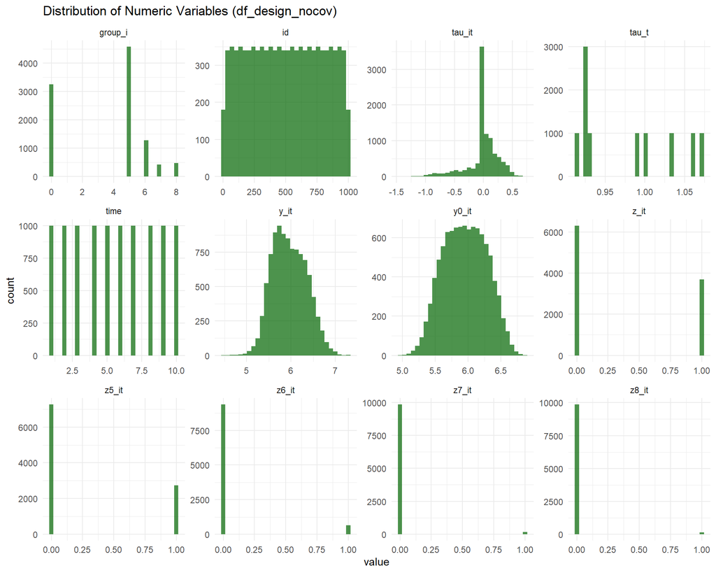

```r
# Select numeric variables for plotting
numeric_vars <- df_nocov %>% select(where(is.numeric))

if(ncol(numeric_vars) > 0) {
  numeric_vars %>%
    pivot_longer(everything(), names_to = "variable", values_to = "value") %>%
    ggplot(aes(x = value)) +
    geom_histogram(bins = 30, fill = "darkgreen", alpha = 0.7) +
    facet_wrap(~variable, scales = "free") +
    theme_minimal() +
    labs(title = "Distribution of Numeric Variables (df_design_nocov)")
}
```

## ATT Estimation using Callaway and Sant’Anna (2021)

### Estimate Group-Time ATT (Without Covariates)

```r
# Estimate group-time average treatment effects
# No covariates (xformla = ~1 means intercept only)
att_results_nocov <- att_gt(
  yname = "y_it",           # Outcome variable
  tname = "time",            # Time period
  idname = "id",             # Unit identifier
  gname = "group_i",         # Treatment timing (0 for never-treated)
  xformla = ~1,              # No covariates
  data = df_nocov,
  control_group = "nevertreated",  # Use never-treated as comparison
  est_method = "dr"          # Doubly robust estimator
)

# Display summary
summary(att_results_nocov)
```

```
##
## Call:
## att_gt(yname = "y_it", tname = "time", idname = "id", gname = "group_i",
##     xformla = ~1, data = df_nocov, control_group = "nevertreated",
##     est_method = "dr")
##
## Reference: Callaway, Brantly and Pedro H.C. Sant'Anna.  "Difference-in-Differences with Multiple Time Periods." Journal of Econometrics, Vol. 225, No. 2, pp. 200-230, 2021. <https://doi.org/10.1016/j.jeconom.2020.12.001>, <https://arxiv.org/abs/1803.09015>
##
## Group-Time Average Treatment Effects:
##  Group Time ATT(g,t) Std. Error [95% Simult.  Conf. Band]
##      5    2  -0.0017     0.0032       -0.0113      0.0079
##      5    3  -0.0002     0.0034       -0.0101      0.0097
##      5    4   0.0034     0.0031       -0.0057      0.0125
##      5    5   0.1678     0.0067        0.1480      0.1876 *
##      5    6   0.1863     0.0073        0.1647      0.2078 *
##      5    7   0.1726     0.0065        0.1534      0.1919 *
##      5    8   0.1784     0.0068        0.1582      0.1985 *
##      5    9   0.1887     0.0074        0.1669      0.2105 *
##      5   10   0.2019     0.0076        0.1795      0.2243 *
##      6    2  -0.0054     0.0046       -0.0191      0.0082
##      6    3  -0.0022     0.0044       -0.0154      0.0109
##      6    4   0.0064     0.0046       -0.0071      0.0199
##      6    5   0.0002     0.0041       -0.0119      0.0123
##      6    6  -0.4900     0.0300       -0.5786     -0.4013 *
##      6    7  -0.4524     0.0277       -0.5342     -0.3707 *
##      6    8  -0.4535     0.0282       -0.5368     -0.3703 *
##      6    9  -0.4818     0.0294       -0.5688     -0.3948 *
##      6   10  -0.5178     0.0321       -0.6127     -0.4230 *
##      7    2   0.0018     0.0058       -0.0155      0.0190
##      7    3  -0.0116     0.0060       -0.0294      0.0061
##      7    4   0.0075     0.0070       -0.0133      0.0283
##      7    5  -0.0064     0.0062       -0.0249      0.0120
##      7    6   0.0043     0.0068       -0.0158      0.0243
##      7    7  -0.3842     0.0401       -0.5027     -0.2657 *
##      7    8  -0.3769     0.0380       -0.4892     -0.2646 *
##      7    9  -0.4117     0.0421       -0.5361     -0.2874 *
##      7   10  -0.4428     0.0469       -0.5813     -0.3043 *
##      8    2  -0.0114     0.0066       -0.0309      0.0082
##      8    3   0.0090     0.0069       -0.0115      0.0295
##      8    4   0.0012     0.0065       -0.0179      0.0203
##      8    5  -0.0079     0.0066       -0.0275      0.0116
##      8    6   0.0037     0.0071       -0.0175      0.0248
##      8    7  -0.0037     0.0058       -0.0209      0.0135
##      8    8  -0.1486     0.0159       -0.1957     -0.1015 *
##      8    9  -0.1557     0.0178       -0.2083     -0.1031 *
##      8   10  -0.1692     0.0182       -0.2230     -0.1153 *
## ---
## Signif. codes: `*' confidence band does not cover 0
##
## P-value for pre-test of parallel trends assumption:  0.56855
## Control Group:  Never Treated,  Anticipation Periods:  0
## Estimation Method:  Doubly Robust
```

### Aggregate to Overall ATT

```r
# Simple weighted average ATT
att_simple_nocov <- aggte(att_results_nocov, type = "simple")
summary(att_simple_nocov)
```

```
##
## Call:
## aggte(MP = att_results_nocov, type = "simple")
##
## Reference: Callaway, Brantly and Pedro H.C. Sant'Anna.  "Difference-in-Differences with Multiple Time Periods." Journal of Econometrics, Vol. 225, No. 2, pp. 200-230, 2021. <https://doi.org/10.1016/j.jeconom.2020.12.001>, <https://arxiv.org/abs/1803.09015>
##
##
##    ATT    Std. Error     [ 95%  Conf. Int.]
##  0.028        0.0123     0.0039      0.0521 *
##
##
## ---
## Signif. codes: `*' confidence band does not cover 0
##
## Control Group:  Never Treated,  Anticipation Periods:  0
## Estimation Method:  Doubly Robust
```

### Event Study / Dynamic Effects

```r
# Dynamic treatment effects (event study)
att_dynamic_nocov <- aggte(att_results_nocov, type = "dynamic")
summary(att_dynamic_nocov)
```

```
##
## Call:
## aggte(MP = att_results_nocov, type = "dynamic")
##
## Reference: Callaway, Brantly and Pedro H.C. Sant'Anna.  "Difference-in-Differences with Multiple Time Periods." Journal of Econometrics, Vol. 225, No. 2, pp. 200-230, 2021. <https://doi.org/10.1016/j.jeconom.2020.12.001>, <https://arxiv.org/abs/1803.09015>
##
##
## Overall summary of ATT's based on event-study/dynamic aggregation:
##     ATT    Std. Error     [ 95%  Conf. Int.]
##  0.0372        0.0113     0.0151      0.0593 *
##
##
## Dynamic Effects:
##  Event time Estimate Std. Error [95% Simult.  Conf. Band]
##          -6  -0.0114     0.0067       -0.0296      0.0069
##          -5   0.0056     0.0045       -0.0068      0.0180
##          -4  -0.0052     0.0029       -0.0132      0.0028
##          -3  -0.0017     0.0023       -0.0078      0.0045
##          -2   0.0009     0.0022       -0.0049      0.0068
##          -1   0.0023     0.0021       -0.0034      0.0080
##           0  -0.0138     0.0134       -0.0504      0.0228
##           1   0.0058     0.0130       -0.0297      0.0413
##           2  -0.0068     0.0132       -0.0429      0.0293
##           3   0.0020     0.0133       -0.0343      0.0383
##           4   0.0341     0.0144       -0.0053      0.0735
##           5   0.2019     0.0078        0.1806      0.2232 *
## ---
## Signif. codes: `*' confidence band does not cover 0
##
## Control Group:  Never Treated,  Anticipation Periods:  0
## Estimation Method:  Doubly Robust
```

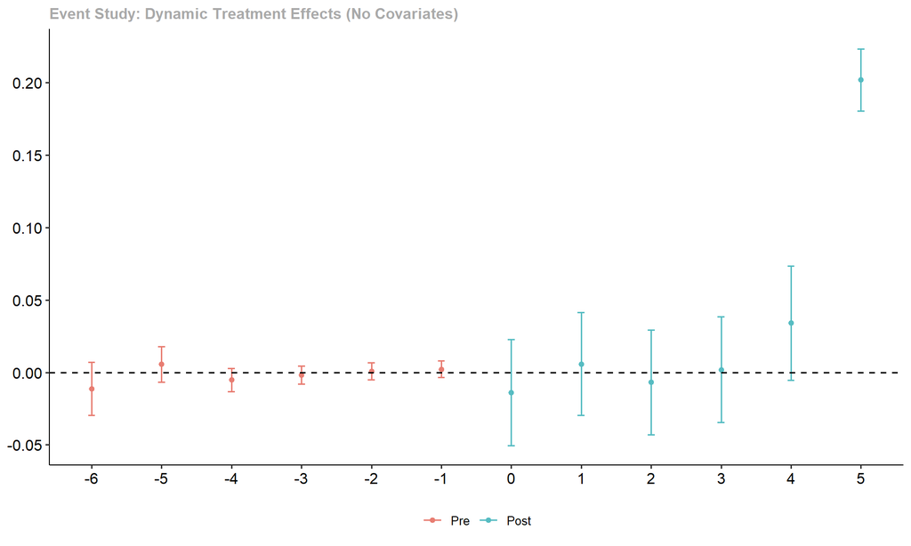

```r
# Plot event study
ggdid(att_dynamic_nocov, title = "Event Study: Dynamic Treatment Effects (No Covariates)")
```

### Group-Specific ATT

```r
# Group-specific average treatment effects
att_group_nocov <- aggte(att_results_nocov, type = "group")
summary(att_group_nocov)
```

```
##
## Call:
## aggte(MP = att_results_nocov, type = "group")
##
## Reference: Callaway, Brantly and Pedro H.C. Sant'Anna.  "Difference-in-Differences with Multiple Time Periods." Journal of Econometrics, Vol. 225, No. 2, pp. 200-230, 2021. <https://doi.org/10.1016/j.jeconom.2020.12.001>, <https://arxiv.org/abs/1803.09015>
##
##
## Overall summary of ATT's based on group/cohort aggregation:
##      ATT    Std. Error     [ 95%  Conf. Int.]
##  -0.0036        0.0286    -0.0597      0.0525
##
##
## Group Effects:
##  Group Estimate Std. Error [95% Simult.  Conf. Band]
##      5   0.1826     0.0072        0.1651      0.2001 *
##      6  -0.4791     0.0274       -0.5460     -0.4122 *
##      7  -0.4039     0.0417       -0.5059     -0.3019 *
##      8  -0.1578     0.0161       -0.1971     -0.1186 *
## ---
## Signif. codes: `*' confidence band does not cover 0
##
## Control Group:  Never Treated,  Anticipation Periods:  0
## Estimation Method:  Doubly Robust
```

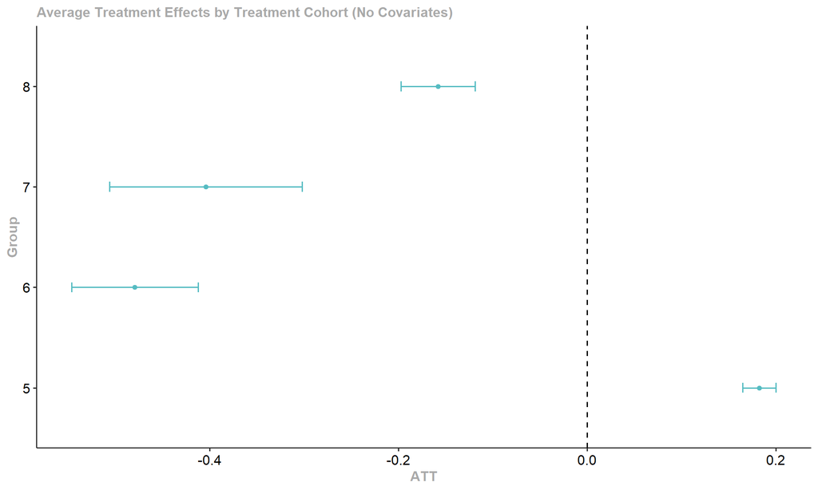

```r
# Plot group-specific effects
ggdid(att_group_nocov, title = "Average Treatment Effects by Treatment Cohort (No Covariates)")
```

### Calendar Time Effects

```r
# Calendar time average treatment effects
att_calendar_nocov <- aggte(att_results_nocov, type = "calendar")
summary(att_calendar_nocov)
```

```
##
## Call:
## aggte(MP = att_results_nocov, type = "calendar")
##
## Reference: Callaway, Brantly and Pedro H.C. Sant'Anna.  "Difference-in-Differences with Multiple Time Periods." Journal of Econometrics, Vol. 225, No. 2, pp. 200-230, 2021. <https://doi.org/10.1016/j.jeconom.2020.12.001>, <https://arxiv.org/abs/1803.09015>
##
##
## Overall summary of ATT's based on calendar time aggregation:
##     ATT    Std. Error     [ 95%  Conf. Int.]
##  0.0355        0.0123     0.0115      0.0596 *
##
##
## Time Effects:
##  Time Estimate Std. Error [95% Simult.  Conf. Band]
##     5   0.1678     0.0070        0.1509      0.1848 *
##     6   0.0383     0.0144        0.0034      0.0732 *
##     7   0.0077     0.0132       -0.0243      0.0398
##     8   0.0007     0.0125       -0.0295      0.0310
##     9  -0.0003     0.0143       -0.0349      0.0343
##    10  -0.0011     0.0141       -0.0354      0.0333
## ---
## Signif. codes: `*' confidence band does not cover 0
##
## Control Group:  Never Treated,  Anticipation Periods:  0
## Estimation Method:  Doubly Robust
```

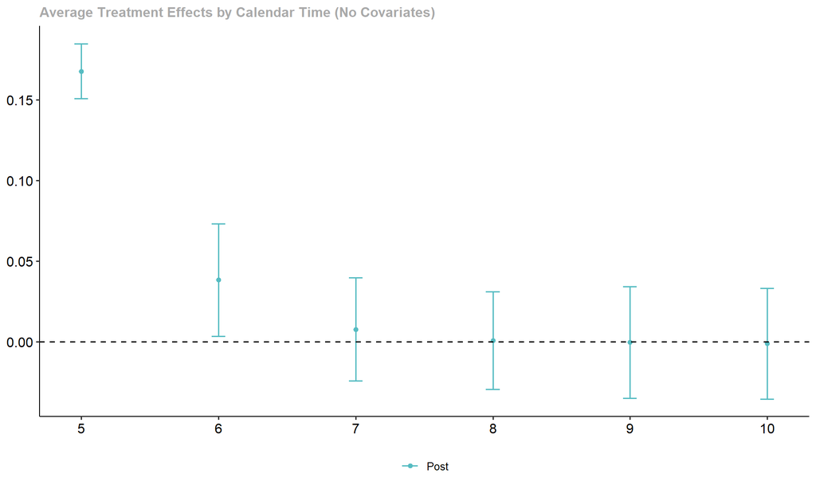

```r
# Plot calendar time effects
ggdid(att_calendar_nocov, title = "Average Treatment Effects by Calendar Time (No Covariates)")
```

# Dataset 3: NYT Design (df_design_nyt)

## Structure

```r
str(df_nyt)
```

```
## tibble [10,000 × 20] (S3: tbl_df/tbl/data.frame)
##  $ id     : int [1:10000] 1 2 3 4 5 6 7 8 9 10 ...
##  $ x1_i   : logi [1:10000] TRUE TRUE FALSE TRUE TRUE TRUE ...
##  $ x2_i   : logi [1:10000] TRUE FALSE FALSE FALSE TRUE TRUE ...
##  $ group_i: num [1:10000] 10 10 10 5 5 5 10 5 6 6 ...
##  $ g5_i   : logi [1:10000] FALSE FALSE FALSE TRUE TRUE TRUE ...
##  $ g6_i   : logi [1:10000] FALSE FALSE FALSE FALSE FALSE FALSE ...
##  $ g7_i   : logi [1:10000] FALSE FALSE FALSE FALSE FALSE FALSE ...
##  $ g8_i   : logi [1:10000] FALSE FALSE FALSE FALSE FALSE FALSE ...
##  $ g10_i  : logi [1:10000] TRUE TRUE TRUE FALSE FALSE FALSE ...
##  $ time   : int [1:10000] 1 1 1 1 1 1 1 1 1 1 ...
##  $ tau_it : num [1:10000] 0 0 0 0.1887 0.0822 ...
##  $ tau_t  : num [1:10000] 0.926 0.926 0.926 0.926 0.926 ...
##  $ z_it   : num [1:10000] 0 0 0 0 0 0 0 0 0 0 ...
##  $ z5_it  : num [1:10000] 0 0 0 0 0 0 0 0 0 0 ...
##  $ z6_it  : num [1:10000] 0 0 0 0 0 0 0 0 0 0 ...
##  $ z7_it  : num [1:10000] 0 0 0 0 0 0 0 0 0 0 ...
##  $ z8_it  : num [1:10000] 0 0 0 0 0 0 0 0 0 0 ...
##  $ z10_it : num [1:10000] 0 0 0 0 0 0 0 0 0 0 ...
##  $ y0_it  : num [1:10000] 5.43 5.54 5.41 5.24 5.4 ...
##  $ y_it   : num [1:10000] 5.43 5.54 5.41 5.24 5.4 ...
```

## Summary Statistics

### Numeric Variables

```r
numeric_vars <- df_nyt %>% select(where(is.numeric))
if(ncol(numeric_vars) > 0) {
  numeric_summary <- data.frame(
    Variable = names(numeric_vars),
    Min = sapply(numeric_vars, min, na.rm = TRUE),
    Q1 = sapply(numeric_vars, quantile, 0.25, na.rm = TRUE),
    Median = sapply(numeric_vars, median, na.rm = TRUE),
    Mean = sapply(numeric_vars, mean, na.rm = TRUE),
    Q3 = sapply(numeric_vars, quantile, 0.75, na.rm = TRUE),
    Max = sapply(numeric_vars, max, na.rm = TRUE),
    SD = sapply(numeric_vars, sd, na.rm = TRUE),
    N_Missing = sapply(numeric_vars, function(x) sum(is.na(x)))
  )
  rownames(numeric_summary) <- NULL

  numeric_summary %>%
    kable(digits = 3) %>%
    kable_styling(bootstrap_options = c("striped", "hover", "condensed"))
}
```

| Variable | Min | Q1 | Median | Mean | Q3 | Max | SD | N_Missing |
| --- | --- | --- | --- | --- | --- | --- | --- | --- |
| id | 1.000 | 250.750 | 500.500 | 500.500 | 750.250 | 1000.000 | 288.689 | 0 |
| group_i | 5.000 | 5.000 | 6.000 | 6.981 | 10.000 | 10.000 | 2.220 | 0 |
| time | 1.000 | 3.000 | 5.500 | 5.500 | 8.000 | 10.000 | 2.872 | 0 |
| tau_it | -1.440 | 0.000 | 0.000 | -0.002 | 0.130 | 0.721 | 0.278 | 0 |
| tau_t | 0.914 | 0.926 | 0.962 | 0.979 | 1.035 | 1.072 | 0.059 | 0 |
| z_it | 0.000 | 0.000 | 0.000 | 0.402 | 1.000 | 1.000 | 0.490 | 0 |
| z5_it | 0.000 | 0.000 | 0.000 | 0.274 | 1.000 | 1.000 | 0.446 | 0 |
| z6_it | 0.000 | 0.000 | 0.000 | 0.064 | 0.000 | 1.000 | 0.245 | 0 |
| z7_it | 0.000 | 0.000 | 0.000 | 0.017 | 0.000 | 1.000 | 0.129 | 0 |
| z8_it | 0.000 | 0.000 | 0.000 | 0.014 | 0.000 | 1.000 | 0.119 | 0 |
| z10_it | 0.000 | 0.000 | 0.000 | 0.032 | 0.000 | 1.000 | 0.177 | 0 |
| y0_it | 4.963 | 5.699 | 5.952 | 5.953 | 6.208 | 6.868 | 0.328 | 0 |
| y_it | 4.476 | 5.670 | 5.936 | 5.963 | 6.249 | 7.291 | 0.385 | 0 |

### Logical Variables

```r
logical_vars <- df_nyt %>% select(where(is.logical))
if(ncol(logical_vars) > 0) {
  logical_summary <- data.frame(
    Variable = names(logical_vars),
    N_TRUE = sapply(logical_vars, function(x) sum(x, na.rm = TRUE)),
    N_FALSE = sapply(logical_vars, function(x) sum(!x, na.rm = TRUE)),
    N_Missing = sapply(logical_vars, function(x) sum(is.na(x))),
    Prop_TRUE = sapply(logical_vars, function(x) mean(x, na.rm = TRUE))
  )
  rownames(logical_summary) <- NULL

  logical_summary %>%
    kable(digits = 3) %>%
    kable_styling(bootstrap_options = c("striped", "hover", "condensed"))
}
```

| Variable | N_TRUE | N_FALSE | N_Missing | Prop_TRUE |
| --- | --- | --- | --- | --- |
| x1_i | 6890 | 3110 | 0 | 0.689 |
| x2_i | 3200 | 6800 | 0 | 0.320 |
| g5_i | 4570 | 5430 | 0 | 0.457 |
| g6_i | 1280 | 8720 | 0 | 0.128 |
| g7_i | 420 | 9580 | 0 | 0.042 |
| g8_i | 480 | 9520 | 0 | 0.048 |
| g10_i | 3250 | 6750 | 0 | 0.325 |

### Character Variables

```r
character_vars <- df_nyt %>% select(where(is.character))
if(ncol(character_vars) > 0) {
  character_summary <- data.frame(
    Variable = names(character_vars),
    N_Unique = sapply(character_vars, function(x) length(unique(x))),
    N_Missing = sapply(character_vars, function(x) sum(is.na(x) | x == "")),
    Most_Common = sapply(character_vars, function(x) {
      tbl <- table(x)
      if(length(tbl) > 0) names(tbl)[which.max(tbl)] else NA
    }),
    Most_Common_Count = sapply(character_vars, function(x) {
      tbl <- table(x)
      if(length(tbl) > 0) max(tbl) else NA
    })
  )
  rownames(character_summary) <- NULL

  character_summary %>%
    kable(digits = 3) %>%
    kable_styling(bootstrap_options = c("striped", "hover", "condensed"))
}
```

## Dimensions

```r
cat("Number of observations:", nrow(df_nyt), "\n")
```

```
## Number of observations: 10000
```

```r
cat("Number of variables:", ncol(df_nyt), "\n")
```

```
## Number of variables: 20
```

## First Few Rows

```r
head(df_nyt, 10) %>%
  kable() %>%
  kable_styling(bootstrap_options = c("striped", "hover", "condensed")) %>%
  scroll_box(width = "100%")
```

| id | x1_i | x2_i | group_i | g5_i | g6_i | g7_i | g8_i | g10_i | time | tau_it | tau_t | z_it | z5_it | z6_it | z7_it | z8_it | z10_it | y0_it | y_it |
| --- | --- | --- | --- | --- | --- | --- | --- | --- | --- | --- | --- | --- | --- | --- | --- | --- | --- | --- | --- |
| 1 | TRUE | TRUE | 10 | FALSE | FALSE | FALSE | FALSE | TRUE | 1 | 0.0000000 | 0.925653 | 0 | 0 | 0 | 0 | 0 | 0 | 5.428205 | 5.428205 |
| 2 | TRUE | FALSE | 10 | FALSE | FALSE | FALSE | FALSE | TRUE | 1 | 0.0000000 | 0.925653 | 0 | 0 | 0 | 0 | 0 | 0 | 5.539145 | 5.539145 |
| 3 | FALSE | FALSE | 10 | FALSE | FALSE | FALSE | FALSE | TRUE | 1 | 0.0000000 | 0.925653 | 0 | 0 | 0 | 0 | 0 | 0 | 5.413548 | 5.413548 |
| 4 | TRUE | FALSE | 5 | TRUE | FALSE | FALSE | FALSE | FALSE | 1 | 0.1886981 | 0.925653 | 0 | 0 | 0 | 0 | 0 | 0 | 5.236601 | 5.236601 |
| 5 | TRUE | TRUE | 5 | TRUE | FALSE | FALSE | FALSE | FALSE | 1 | 0.0822258 | 0.925653 | 0 | 0 | 0 | 0 | 0 | 0 | 5.402495 | 5.402495 |
| 6 | TRUE | TRUE | 5 | TRUE | FALSE | FALSE | FALSE | FALSE | 1 | 0.2214935 | 0.925653 | 0 | 0 | 0 | 0 | 0 | 0 | 5.651068 | 5.651068 |
| 7 | FALSE | FALSE | 10 | FALSE | FALSE | FALSE | FALSE | TRUE | 1 | 0.0000000 | 0.925653 | 0 | 0 | 0 | 0 | 0 | 0 | 5.627297 | 5.627297 |
| 8 | TRUE | FALSE | 5 | TRUE | FALSE | FALSE | FALSE | FALSE | 1 | 0.1500083 | 0.925653 | 0 | 0 | 0 | 0 | 0 | 0 | 5.387556 | 5.387556 |
| 9 | TRUE | TRUE | 6 | FALSE | TRUE | FALSE | FALSE | FALSE | 1 | -0.7511980 | 0.925653 | 0 | 0 | 0 | 0 | 0 | 0 | 5.470210 | 5.470210 |
| 10 | TRUE | TRUE | 6 | FALSE | TRUE | FALSE | FALSE | FALSE | 1 | -0.1351090 | 0.925653 | 0 | 0 | 0 | 0 | 0 | 0 | 5.593160 | 5.593160 |

## Variable Distribution

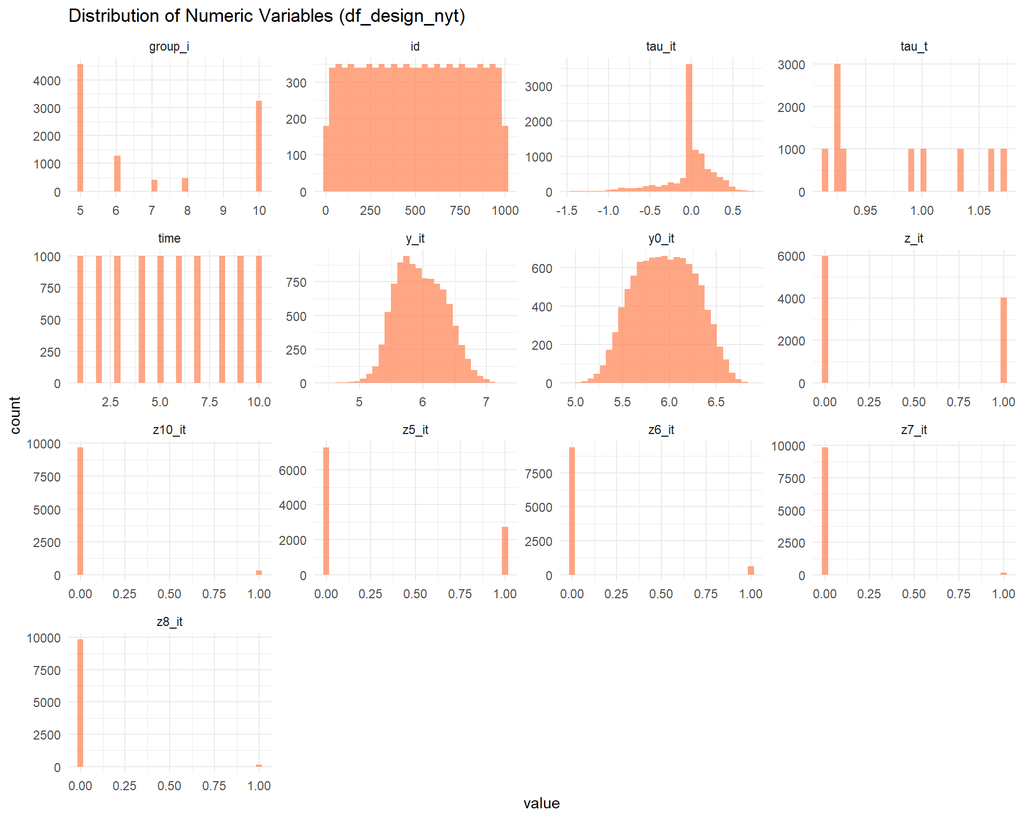

```r
# Select numeric variables for plotting
numeric_vars <- df_nyt %>% select(where(is.numeric))

if(ncol(numeric_vars) > 0) {
  numeric_vars %>%
    pivot_longer(everything(), names_to = "variable", values_to = "value") %>%
    ggplot(aes(x = value)) +
    geom_histogram(bins = 30, fill = "coral", alpha = 0.7) +
    facet_wrap(~variable, scales = "free") +
    theme_minimal() +
    labs(title = "Distribution of Numeric Variables (df_design_nyt)")
}
```

## ATT Estimation using Callaway and Sant’Anna (2021)

### Estimate Group-Time ATT (Not-Yet-Treated Control)

```r
# Estimate group-time average treatment effects
# Using not-yet-treated as control (no never-treated group available)
att_results_nyt <- att_gt(
  yname = "y_it",           # Outcome variable
  tname = "time",            # Time period
  idname = "id",             # Unit identifier
  gname = "group_i",         # Treatment timing (no 0 group in this dataset)
  xformla = ~x1_i + x2_i,    # Covariates
  data = df_nyt,
  control_group = "notyettreated",  # Use not-yet-treated as comparison
  est_method = "dr"          # Doubly robust estimator
)

# Display summary
summary(att_results_nyt)
```

```
##
## Call:
## att_gt(yname = "y_it", tname = "time", idname = "id", gname = "group_i",
##     xformla = ~x1_i + x2_i, data = df_nyt, control_group = "notyettreated",
##     est_method = "dr")
##
## Reference: Callaway, Brantly and Pedro H.C. Sant'Anna.  "Difference-in-Differences with Multiple Time Periods." Journal of Econometrics, Vol. 225, No. 2, pp. 200-230, 2021. <https://doi.org/10.1016/j.jeconom.2020.12.001>, <https://arxiv.org/abs/1803.09015>
##
## Group-Time Average Treatment Effects:
##  Group Time ATT(g,t) Std. Error [95% Simult.  Conf. Band]
##      5    2   0.0004     0.0027       -0.0076      0.0085
##      5    3   0.0004     0.0027       -0.0076      0.0084
##      5    4   0.0013     0.0026       -0.0064      0.0091
##      5    5   0.1688     0.0067        0.1489      0.1888 *
##      5    6   0.1873     0.0076        0.1648      0.2098 *
##      5    7   0.1755     0.0069        0.1551      0.1960 *
##      5    8   0.1827     0.0075        0.1605      0.2049 *
##      5    9   0.1910     0.0074        0.1690      0.2130 *
##      6    2  -0.0045     0.0042       -0.0168      0.0079
##      6    3  -0.0015     0.0046       -0.0152      0.0121
##      6    4   0.0028     0.0040       -0.0091      0.0148
##      6    5   0.0064     0.0046       -0.0073      0.0202
##      6    6  -0.4938     0.0291       -0.5798     -0.4078 *
##      6    7  -0.4526     0.0274       -0.5336     -0.3717 *
##      6    8  -0.4498     0.0273       -0.5305     -0.3692 *
##      6    9  -0.4832     0.0287       -0.5680     -0.3983 *
##      7    2   0.0033     0.0064       -0.0157      0.0223
##      7    3  -0.0106     0.0059       -0.0280      0.0069
##      7    4   0.0034     0.0069       -0.0169      0.0238
##      7    5  -0.0039     0.0068       -0.0240      0.0163
##      7    6   0.0044     0.0085       -0.0209      0.0296
##      7    7  -0.3799     0.0395       -0.4966     -0.2633 *
##      7    8  -0.3685     0.0396       -0.4856     -0.2514 *
##      7    9  -0.4096     0.0411       -0.5310     -0.2882 *
##      8    2  -0.0104     0.0063       -0.0289      0.0082
##      8    3   0.0109     0.0064       -0.0081      0.0299
##      8    4  -0.0031     0.0055       -0.0193      0.0131
##      8    5  -0.0047     0.0067       -0.0246      0.0152
##      8    6   0.0006     0.0070       -0.0202      0.0213
##      8    7  -0.0012     0.0066       -0.0208      0.0184
##      8    8  -0.1450     0.0169       -0.1950     -0.0950 *
##      8    9  -0.1573     0.0189       -0.2131     -0.1015 *
## ---
## Signif. codes: `*' confidence band does not cover 0
##
## P-value for pre-test of parallel trends assumption:  0.65994
## Control Group:  Not Yet Treated,  Anticipation Periods:  0
## Estimation Method:  Doubly Robust
```

### Aggregate to Overall ATT

```r
# Simple weighted average ATT
att_simple_nyt <- aggte(att_results_nyt, type = "simple")
summary(att_simple_nyt)
```

```
##
## Call:
## aggte(MP = att_results_nyt, type = "simple")
##
## Reference: Callaway, Brantly and Pedro H.C. Sant'Anna.  "Difference-in-Differences with Multiple Time Periods." Journal of Econometrics, Vol. 225, No. 2, pp. 200-230, 2021. <https://doi.org/10.1016/j.jeconom.2020.12.001>, <https://arxiv.org/abs/1803.09015>
##
##
##     ATT    Std. Error     [ 95%  Conf. Int.]
##  0.0365        0.0125      0.012       0.061 *
##
##
## ---
## Signif. codes: `*' confidence band does not cover 0
##
## Control Group:  Not Yet Treated,  Anticipation Periods:  0
## Estimation Method:  Doubly Robust
```

### Event Study / Dynamic Effects

```r
# Dynamic treatment effects (event study)
att_dynamic_nyt <- aggte(att_results_nyt, type = "dynamic")
summary(att_dynamic_nyt)
```

```
##
## Call:
## aggte(MP = att_results_nyt, type = "dynamic")
##
## Reference: Callaway, Brantly and Pedro H.C. Sant'Anna.  "Difference-in-Differences with Multiple Time Periods." Journal of Econometrics, Vol. 225, No. 2, pp. 200-230, 2021. <https://doi.org/10.1016/j.jeconom.2020.12.001>, <https://arxiv.org/abs/1803.09015>
##
##
## Overall summary of ATT's based on event-study/dynamic aggregation:
##     ATT    Std. Error     [ 95%  Conf. Int.]
##  0.0461         0.011     0.0245      0.0676 *
##
##
## Dynamic Effects:
##  Event time Estimate Std. Error [95% Simult.  Conf. Band]
##          -6  -0.0104     0.0068       -0.0287      0.0079
##          -5   0.0074     0.0049       -0.0058      0.0206
##          -4  -0.0053     0.0030       -0.0136      0.0029
##          -3  -0.0001     0.0022       -0.0060      0.0058
##          -2   0.0006     0.0022       -0.0053      0.0065
##          -1   0.0023     0.0022       -0.0036      0.0082
##           0  -0.0133     0.0130       -0.0484      0.0219
##           1   0.0069     0.0135       -0.0297      0.0434
##           2   0.0087     0.0142       -0.0298      0.0471
##           3   0.0370     0.0133        0.0009      0.0731 *
##           4   0.1910     0.0075        0.1707      0.2113 *
## ---
## Signif. codes: `*' confidence band does not cover 0
##
## Control Group:  Not Yet Treated,  Anticipation Periods:  0
## Estimation Method:  Doubly Robust
```

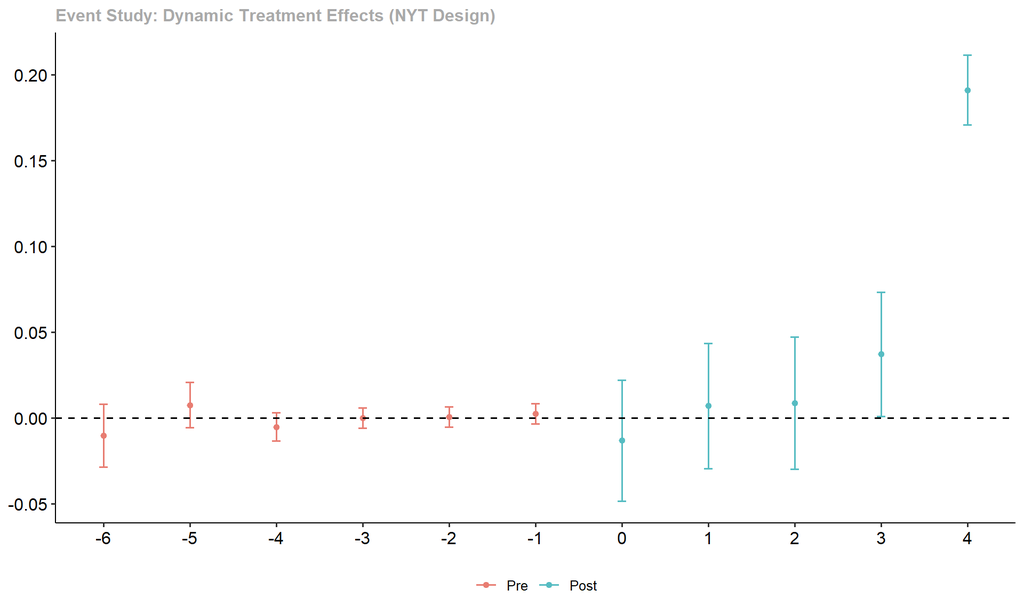

```r
# Plot event study
ggdid(att_dynamic_nyt, title = "Event Study: Dynamic Treatment Effects (NYT Design)")
```

### Group-Specific ATT

```r
# Group-specific average treatment effects
att_group_nyt <- aggte(att_results_nyt, type = "group")
summary(att_group_nyt)
```

```
##
## Call:
## aggte(MP = att_results_nyt, type = "group")
##
## Reference: Callaway, Brantly and Pedro H.C. Sant'Anna.  "Difference-in-Differences with Multiple Time Periods." Journal of Econometrics, Vol. 225, No. 2, pp. 200-230, 2021. <https://doi.org/10.1016/j.jeconom.2020.12.001>, <https://arxiv.org/abs/1803.09015>
##
##
## Overall summary of ATT's based on group/cohort aggregation:
##      ATT    Std. Error     [ 95%  Conf. Int.]
##  -0.0013        0.0279    -0.0559      0.0534
##
##
## Group Effects:
##  Group Estimate Std. Error [95% Simult.  Conf. Band]
##      5   0.1811     0.0069        0.1641      0.1981 *
##      6  -0.4699     0.0268       -0.5362     -0.4036 *
##      7  -0.3860     0.0393       -0.4834     -0.2887 *
##      8  -0.1511     0.0159       -0.1906     -0.1117 *
## ---
## Signif. codes: `*' confidence band does not cover 0
##
## Control Group:  Not Yet Treated,  Anticipation Periods:  0
## Estimation Method:  Doubly Robust
```

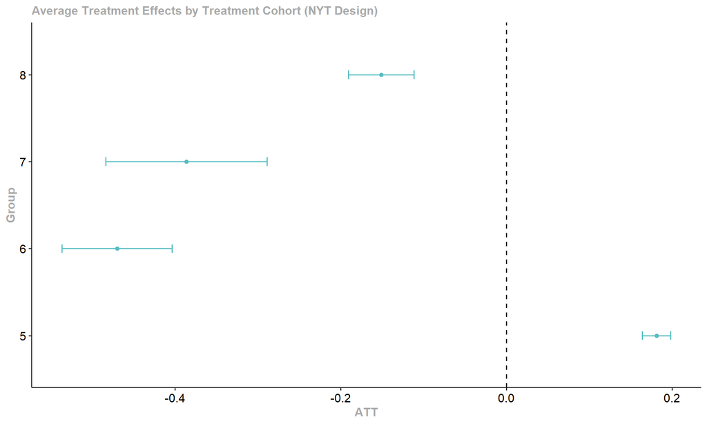

```r
# Plot group-specific effects
ggdid(att_group_nyt, title = "Average Treatment Effects by Treatment Cohort (NYT Design)")
```

### Calendar Time Effects

```r
# Calendar time average treatment effects
att_calendar_nyt <- aggte(att_results_nyt, type = "calendar")
summary(att_calendar_nyt)
```

```
##
## Call:
## aggte(MP = att_results_nyt, type = "calendar")
##
## Reference: Callaway, Brantly and Pedro H.C. Sant'Anna.  "Difference-in-Differences with Multiple Time Periods." Journal of Econometrics, Vol. 225, No. 2, pp. 200-230, 2021. <https://doi.org/10.1016/j.jeconom.2020.12.001>, <https://arxiv.org/abs/1803.09015>
##
##
## Overall summary of ATT's based on calendar time aggregation:
##     ATT    Std. Error     [ 95%  Conf. Int.]
##  0.0447        0.0107     0.0237      0.0657 *
##
##
## Time Effects:
##  Time Estimate Std. Error [95% Simult.  Conf. Band]
##     5   0.1688     0.0066        0.1536      0.1841 *
##     6   0.0383     0.0140        0.0059      0.0707 *
##     7   0.0101     0.0132       -0.0204      0.0406
##     8   0.0052     0.0124       -0.0235      0.0339
##     9   0.0010     0.0137       -0.0306      0.0327
## ---
## Signif. codes: `*' confidence band does not cover 0
##
## Control Group:  Not Yet Treated,  Anticipation Periods:  0
## Estimation Method:  Doubly Robust
```

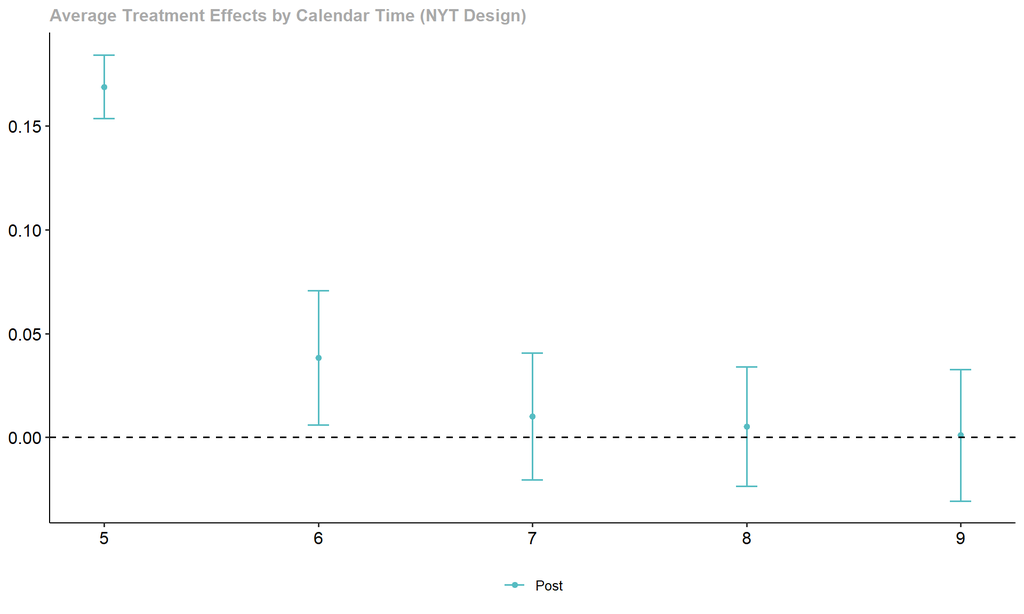

```r
# Plot calendar time effects
ggdid(att_calendar_nyt, title = "Average Treatment Effects by Calendar Time (NYT Design)")
```

# Dataset Comparison

## Size Comparison

```r
data.frame(
  Dataset = c("df_design_cov", "df_design_nocov", "df_design_nyt"),
  Observations = c(nrow(df_cov), nrow(df_nocov), nrow(df_nyt)),
  Variables = c(ncol(df_cov), ncol(df_nocov), ncol(df_nyt))
) %>%
  kable() %>%
  kable_styling(bootstrap_options = c("striped", "hover", "condensed"))
```

| Dataset | Observations | Variables |
| --- | --- | --- |
| df_design_cov | 10000 | 20 |
| df_design_nocov | 10000 | 18 |
| df_design_nyt | 10000 | 20 |

## Variable Names Comparison

```r
data.frame(
  df_design_cov = names(df_cov) %>% paste(collapse = ", "),
  df_design_nocov = names(df_nocov) %>% paste(collapse = ", "),
  df_design_nyt = names(df_nyt) %>% paste(collapse = ", ")
) %>%
  pivot_longer(everything(), names_to = "Dataset", values_to = "Variables") %>%
  kable() %>%
  kable_styling(bootstrap_options = c("striped", "hover", "condensed"))
```

| Dataset | Variables |
| --- | --- |
| df_design_cov | id, x1_i, x2_i, group_i, g5_i, g6_i, g7_i, g8_i, time, tau_it, tau_t, z_it, z5_it, z6_it, z7_it, z8_it, y0_it, y_it, group, groupx |
| df_design_nocov | id, x1_i, x2_i, group_i, g5_i, g6_i, g7_i, g8_i, time, tau_it, tau_t, z_it, z5_it, z6_it, z7_it, z8_it, y0_it, y_it |
| df_design_nyt | id, x1_i, x2_i, group_i, g5_i, g6_i, g7_i, g8_i, g10_i, time, tau_it, tau_t, z_it, z5_it, z6_it, z7_it, z8_it, z10_it, y0_it, y_it |

# Conclusion

This report provides a comprehensive description of the three difference-in-differences multi-period datasets. Each dataset has been examined for its structure, summary statistics, dimensions, and variable distributions.